# hw3_p2_churn

Brandon Owens

2024-02-19

## Introduction

This problem is based on one of [Kaggle’s Playground Series of competitions](https://www.kaggle.com/docs/competitions). The Playground Series is a nice way to practice building predictive models by “providing interesting and approachable datasets for our community to practice their machine learning skills”.

You do **NOT** need to download any data from Kaggle. I’ve created a smaller dataset with some other modifications for use in our HW problem. The datafile, `churn.csv`, is available in the `data` subfolder.

This particular [playground dataset involves data about bank customers](https://www.kaggle.com/competitions/playground-series-s4e1) with the target variable being a binary indicator of whether or not the customer left the bank (`Exited`), or “churned”. The playground dataset was constructed using another [Kaggle dataset on bank customer churn prediction](https://www.kaggle.com/datasets/shubhammeshram579/bank-customer-churn-prediction). Follow the preceeding link for information about the variables in this dataset.

This assignment will focus on building simple classification models for predicting bank customer churn. You’ll be doing your work right in this R Markdown document. Feel free to save it first with a modified filename that includes your name. For example, mine would be **hw3_p2_churn_isken.Rmd**.

You’ll likely need a bunch of libraries. I’ve included a few here but you should add any others that you need. If you don’t need some of these, feel free to delete such lines.

```r
library(dplyr)   # Group by analysis and other SQLish things.
```

```r
library(ggplot2) # Plotting, of course
library(corrplot) # Correlation plots
library(caret)   # Many aspects of predictive modeling
library(skimr)  # An automated EDA tool
library(rpart)
library(rpart.plot)
```

**MAJOR (10%) HACKER EXTRA** Version control

Create a new R Project for this assignment. Put the project under version control with git. Create a private GitHub repository for this project. Use git and GitHub as you go to do commits periodically and push them to your remote repository. After you have completed the assignment and pushed your last commit to your GitHub repo, add me as a Collaborator (my GitHub username is misken) so that I can see your repo.

I cover use of git and GitHub with R Studio in this module on our course web page:

- http://www.sba.oakland.edu/faculty/isken/courses/mis5470_f23/git_intro.html

This Hacker Extra is worth 10% of the total number of points in the assignment.

## Step 1: Read in data

Read the `churn.csv` file from the `data` subfolder into a dataframe named `churn`.

```r
churn <- read.csv("data/churn.csv")
```

```r
str(churn)
```

```
## 'data.frame':    33007 obs. of  11 variables:
##  $ CreditScore    : int  678 678 583 645 773 746 607 686 699 668 ...
##  $ Geography      : chr  "France" "Spain" "Germany" "Germany" ...
##  $ Gender         : chr  "Male" "Male" "Male" "Female" ...
##  $ Age            : num  40 37 40 55 35 33 26 45 31 38 ...
##  $ Tenure         : int  10 1 4 8 9 7 1 4 7 4 ...
##  $ Balance        : num  0 138476 81274 120105 0 ...
##  $ NumOfProducts  : int  2 1 1 1 2 2 2 1 2 2 ...
##  $ HasCrCard      : int  1 1 1 1 0 1 1 1 1 1 ...
##  $ IsActiveMember : int  0 0 1 0 1 1 0 0 0 1 ...
##  $ EstimatedSalary: num  184867 106852 170843 125083 87549 ...
##  $ Exited         : int  0 0 0 1 0 0 0 1 0 0 ...
```

```r
summary(churn)
```

```
##   CreditScore     Geography            Gender               Age
##  Min.   :350.0   Length:33007       Length:33007       Min.   :18.00
##  1st Qu.:598.0   Class :character   Class :character   1st Qu.:32.00
##  Median :659.0   Mode  :character   Mode  :character   Median :37.00
##  Mean   :656.4                                         Mean   :38.17
##  3rd Qu.:710.0                                         3rd Qu.:42.00
##  Max.   :850.0                                         Max.   :92.00
##      Tenure          Balance       NumOfProducts     HasCrCard
##  Min.   : 0.000   Min.   :     0   Min.   :1.000   Min.   :0.0000
##  1st Qu.: 3.000   1st Qu.:     0   1st Qu.:1.000   1st Qu.:1.0000
##  Median : 5.000   Median :     0   Median :2.000   Median :1.0000
##  Mean   : 5.034   Mean   : 54785   Mean   :1.555   Mean   :0.7521
##  3rd Qu.: 7.000   3rd Qu.:118992   3rd Qu.:2.000   3rd Qu.:1.0000
##  Max.   :10.000   Max.   :212693   Max.   :4.000   Max.   :1.0000
##  IsActiveMember   EstimatedSalary         Exited
##  Min.   :0.0000   Min.   :    11.58   Min.   :0.0000
##  1st Qu.:0.0000   1st Qu.: 74637.76   1st Qu.:0.0000
##  Median :0.0000   Median :118522.73   Median :0.0000
##  Mean   :0.4977   Mean   :112716.47   Mean   :0.2093
##  3rd Qu.:1.0000   3rd Qu.:155523.48   3rd Qu.:0.0000
##  Max.   :1.0000   Max.   :199992.48   Max.   :1.0000
```

```r
skim(churn)
```

Data summary

| Name | churn |
| --- | --- |
| Number of rows | 33007 |
| Number of columns | 11 |
| _______________________ |  |
| Column type frequency: |  |
| character | 2 |
| numeric | 9 |
| ________________________ |  |
| Group variables | None |

**Variable type: character**

| skim_variable | n_missing | complete_rate | min | max | empty | n_unique | whitespace |
| --- | --- | --- | --- | --- | --- | --- | --- |
| Geography | 0 | 1 | 5 | 7 | 0 | 3 | 0 |
| Gender | 0 | 1 | 4 | 6 | 0 | 2 | 0 |

**Variable type: numeric**

| skim_variable | n_missing | complete_rate | mean | sd | p0 | p25 | p50 | p75 | p100 | hist |
| --- | --- | --- | --- | --- | --- | --- | --- | --- | --- | --- |
| CreditScore | 0 | 1 | 656.44 | 80.20 | 350.00 | 598.00 | 659.0 | 710.0 | 850.0 | ▁▂▇▇▂ |
| Age | 0 | 1 | 38.17 | 8.87 | 18.00 | 32.00 | 37.0 | 42.0 | 92.0 | ▃▇▂▁▁ |
| Tenure | 0 | 1 | 5.03 | 2.80 | 0.00 | 3.00 | 5.0 | 7.0 | 10.0 | ▇▇▇▇▅ |
| Balance | 0 | 1 | 54785.43 | 62611.67 | 0.00 | 0.00 | 0.0 | 118991.8 | 212693.0 | ▇▁▃▂▁ |
| NumOfProducts | 0 | 1 | 1.56 | 0.54 | 1.00 | 1.00 | 2.0 | 2.0 | 4.0 | ▇▇▁▁▁ |
| HasCrCard | 0 | 1 | 0.75 | 0.43 | 0.00 | 1.00 | 1.0 | 1.0 | 1.0 | ▂▁▁▁▇ |
| IsActiveMember | 0 | 1 | 0.50 | 0.50 | 0.00 | 0.00 | 0.0 | 1.0 | 1.0 | ▇▁▁▁▇ |
| EstimatedSalary | 0 | 1 | 112716.47 | 50260.92 | 11.58 | 74637.76 | 118522.7 | 155523.5 | 199992.5 | ▂▆▇▇▇ |
| Exited | 0 | 1 | 0.21 | 0.41 | 0.00 | 0.00 | 0.0 | 0.0 | 1.0 | ▇▁▁▁▂ |

Use `str`, `summary`, and `skim` to get a sense of the data. The binary target variable is `Exited` where 1 indicates that the customer left the bank (they “churned”). You’ll notice that some of the fields are numeric and some are character data. You might also notice that there are fewer variables in our churn dataset than in the original Kaggle versions.

## Step 2: Factor conversions

Some of the variables clearly should be factors. Change all of the variables to factors that you think should be. Include an explanation of why each of these variables should be converted to factors.

```r
churn <- churn  %>%
  mutate(across(c("Geography", "Gender", "Tenure", "NumOfProducts", "HasCrCard", "IsActiveMember", "Exited"), as.factor))
```

> Any variable that includes a binary classifier should be a factor like “Exited”, “HasCrCard”, “IsActiveMember”, and “Gender”. Additionally, converting the geography origin that is in string format as factors helps with potential grouping as does tenure and number of products. Other variables like age, credit score, balance, and estimated salary may be useful to keep how they are at the moment, but I might consider putting some of their values into factored bins for future grouping.

## Step 3 - Partition into training and test sets

We will use the [caret](https://topepo.github.io/caret/) package to do the partitioning of our data into training and test dataframes. Just run this chunk to create training and test datasets. This way we’ll all be working with the same datasets. Notice that the test set is 20% of the full dataset.

```r
set.seed(687)
trainIndex <- createDataPartition(churn$Exited, p = .8,
                                  list = FALSE,
                                  times = 1)

churn_train <- churn[as.vector(trainIndex), ]
churn_test <- churn[-as.vector(trainIndex), ]
```

Find the number of customers and the percentage of customers for the two `Exited` levels. You’ll see that there are about 20% of the bank customers exited.

```r
churn %>%
  group_by(Exited) %>%
  summarise (Counts = n(), Percentage = 100 * round(Counts/nrow(churn), 4))
```

```
## # A tibble: 2 × 3
##   Exited Counts Percentage
##   <fct>   <int>      <dbl>
## 1 0       26099       79.1
## 2 1        6908       20.9
```

## Step 4: EDA

Do some EDA to try to uncover some relationships that may end up being useful in building a predictive model for `Exited`. You learned things in HW2 which should be useful here. You should **ONLY** use `churn_train` for your EDA. You should explore all of the variables.

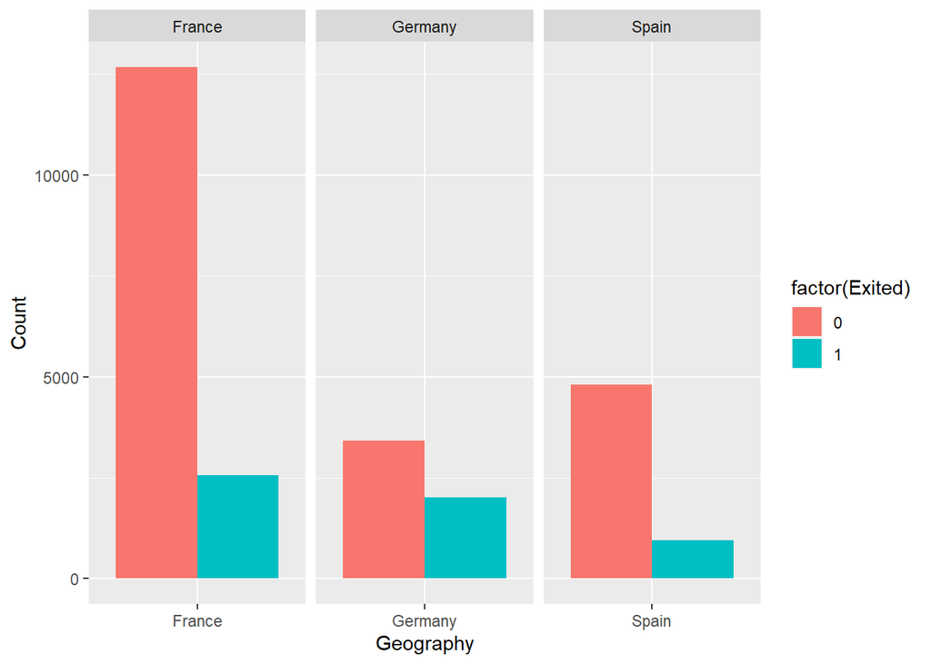

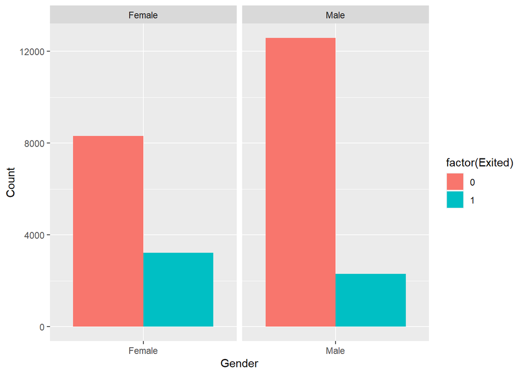

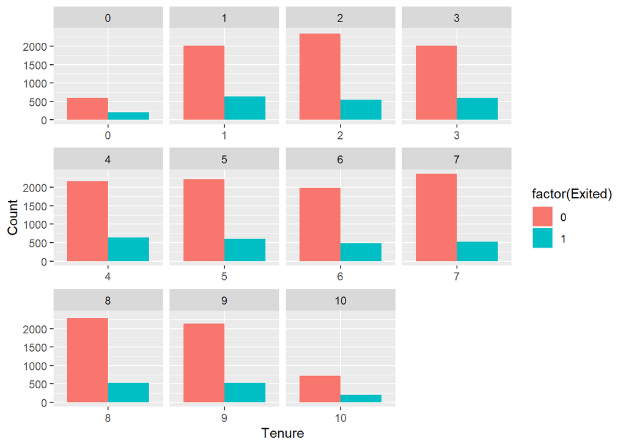

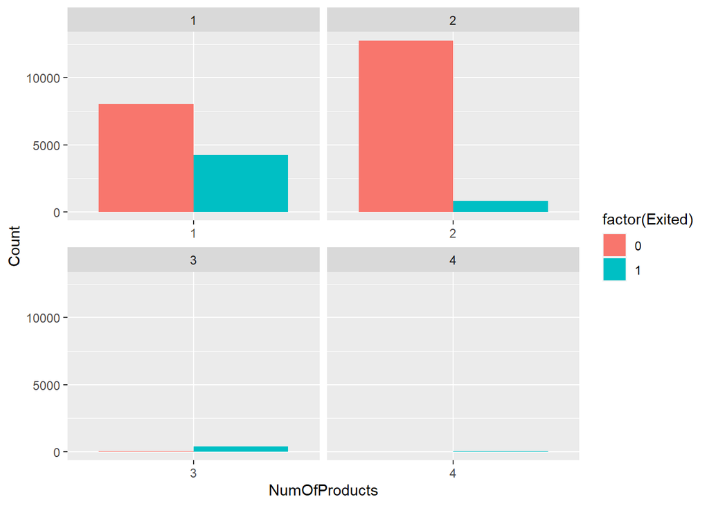

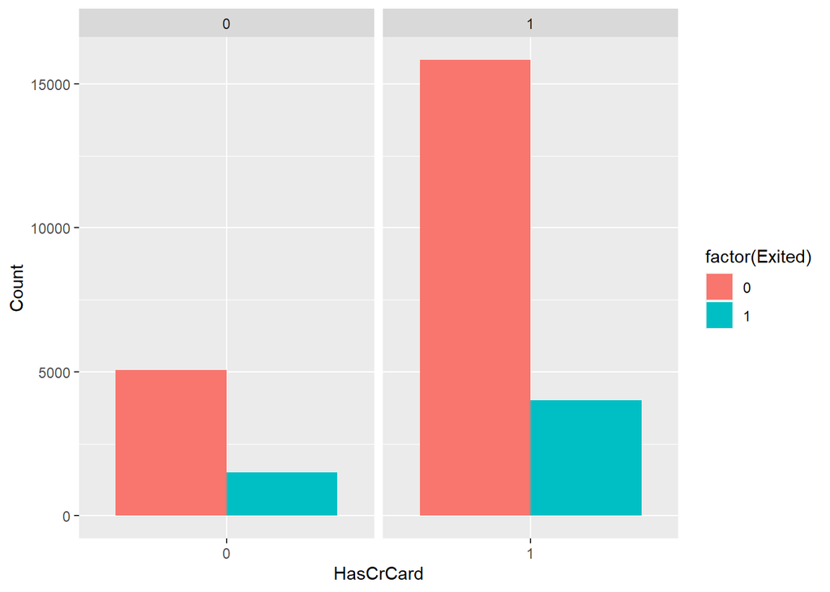

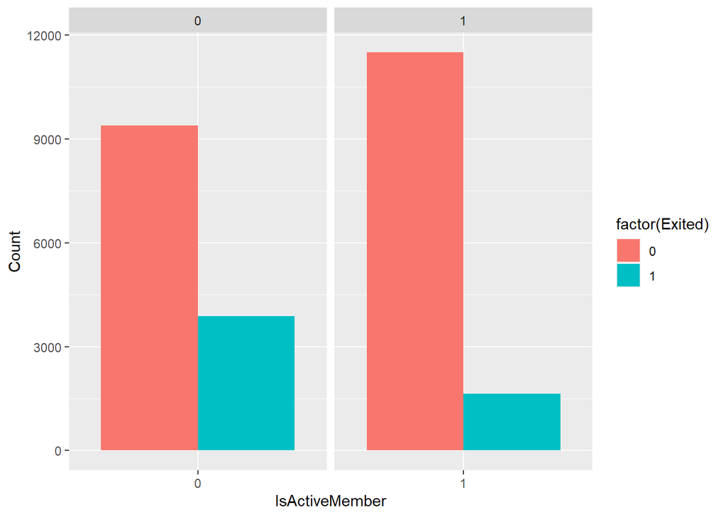

```r
for (i in 1:10) {
  selected_var <- names(churn_train)[i]
  if (is.factor(churn_train[[selected_var]])) {
    temp_data <- churn_train %>%
      group_by(.data[[selected_var]], Exited) %>%
      summarise(Count = n())
    plot <- ggplot(temp_data, aes(x = factor(.data[[selected_var]]), y = Count, fill = factor(Exited))) +
      geom_bar(stat = "identity", position = "dodge") +
      labs(x = selected_var) +
      facet_wrap(~ .data[[selected_var]], scales = "free_x")
    print(plot)
  }
}
```

> Right off of the bat, a high proportion of people in Germany, females, and those that are not active members appear to exit more frequently – independent of one another.

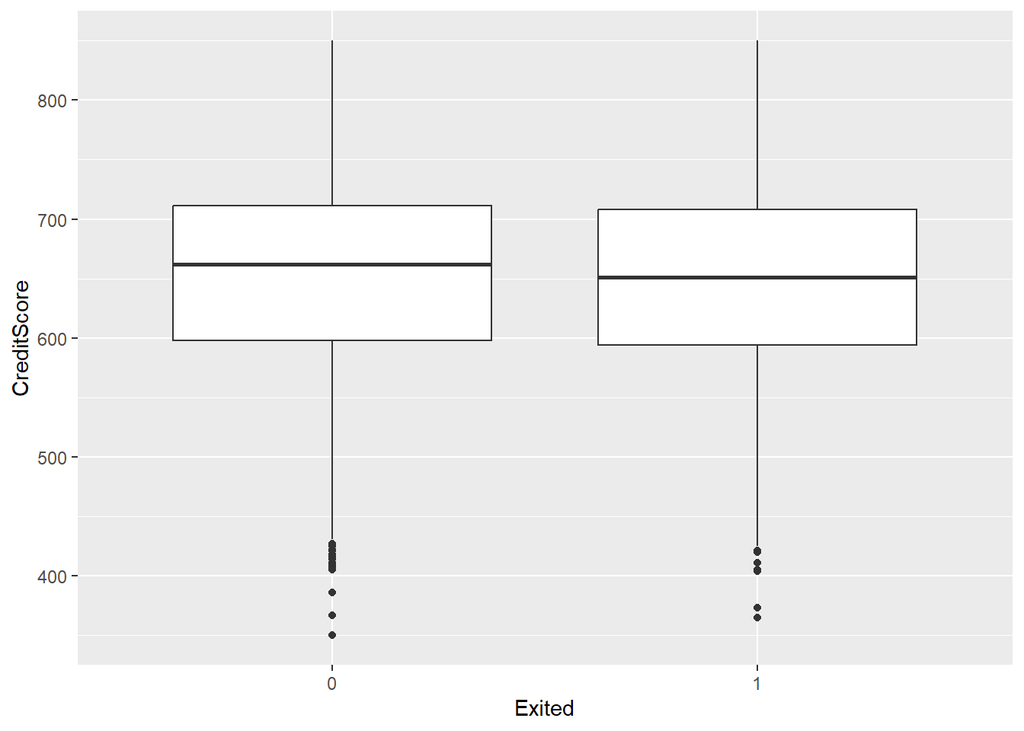

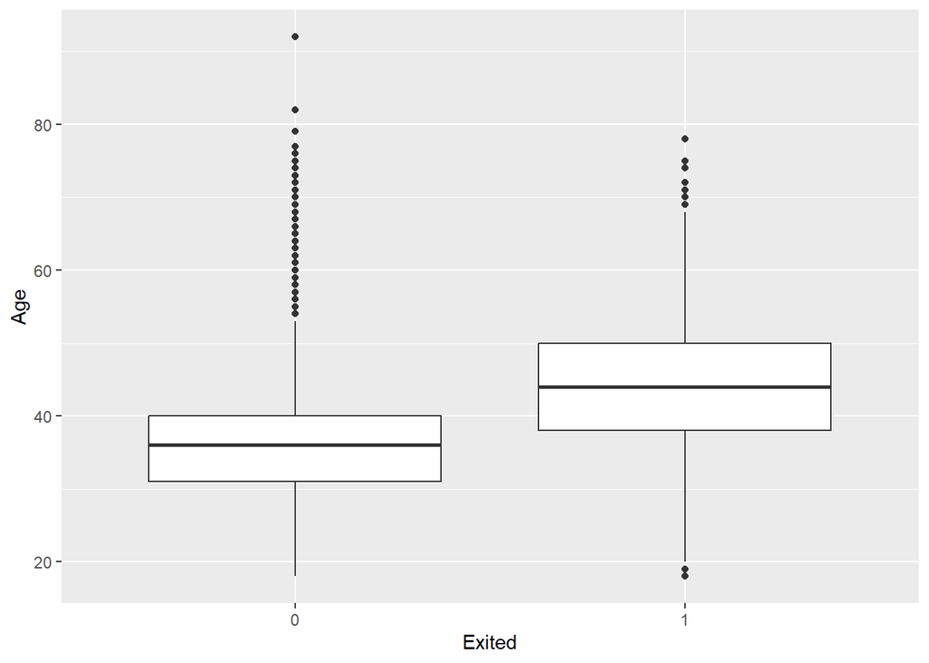

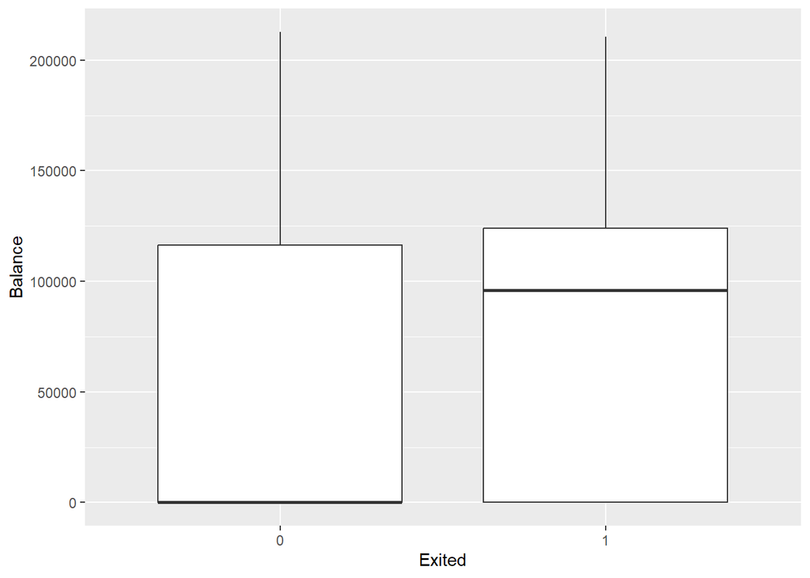

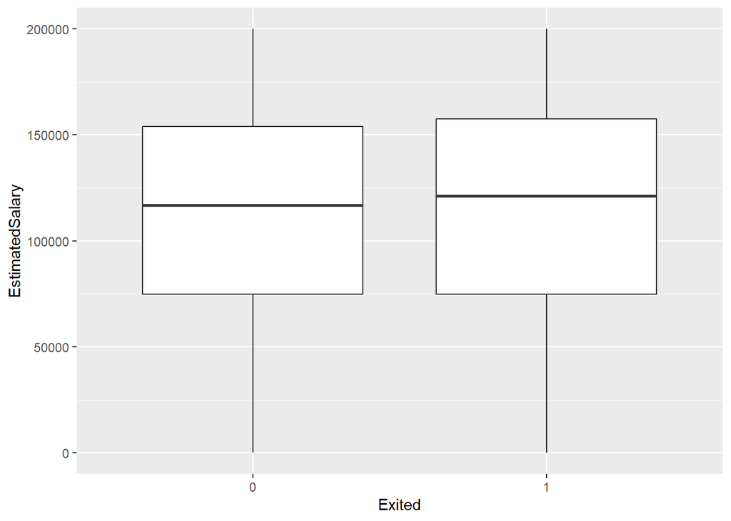

```r
for (i in 1:10) {
  selected_var <- names(churn_train)[i]
  if (!is.factor(churn_train[[selected_var]])) {
    plot <- ggplot(churn_train, aes(x = Exited, y = .data[[selected_var]])) + geom_boxplot() + labs(selected_var)
    print(plot)
  }
}
```

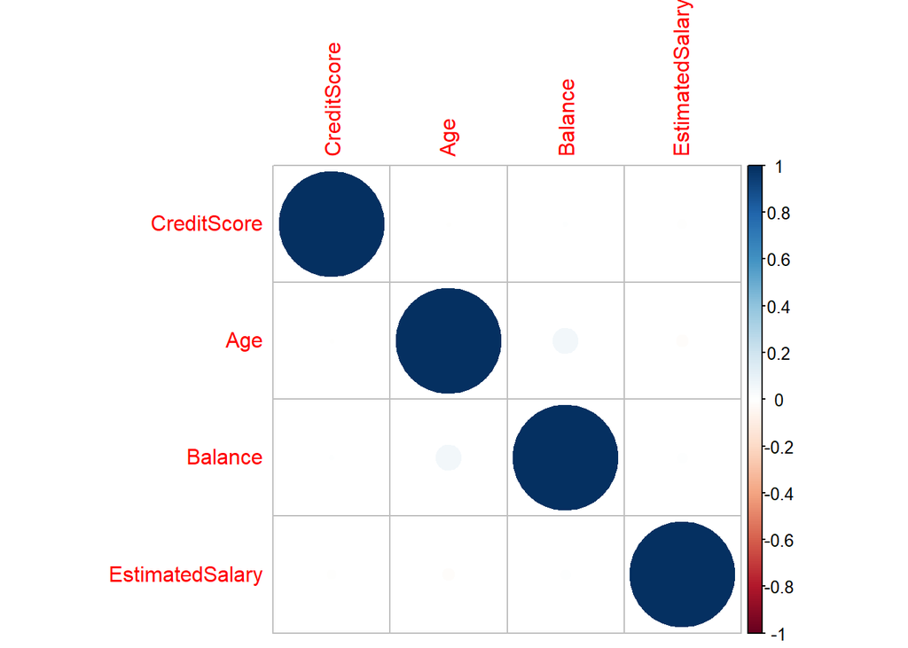

```r
corr_matrix <- cor(select_if(churn_train, is.numeric))
corrplot(corr_matrix)
```

> None of the numeric data seems to be correlated with any of the other numeric data.

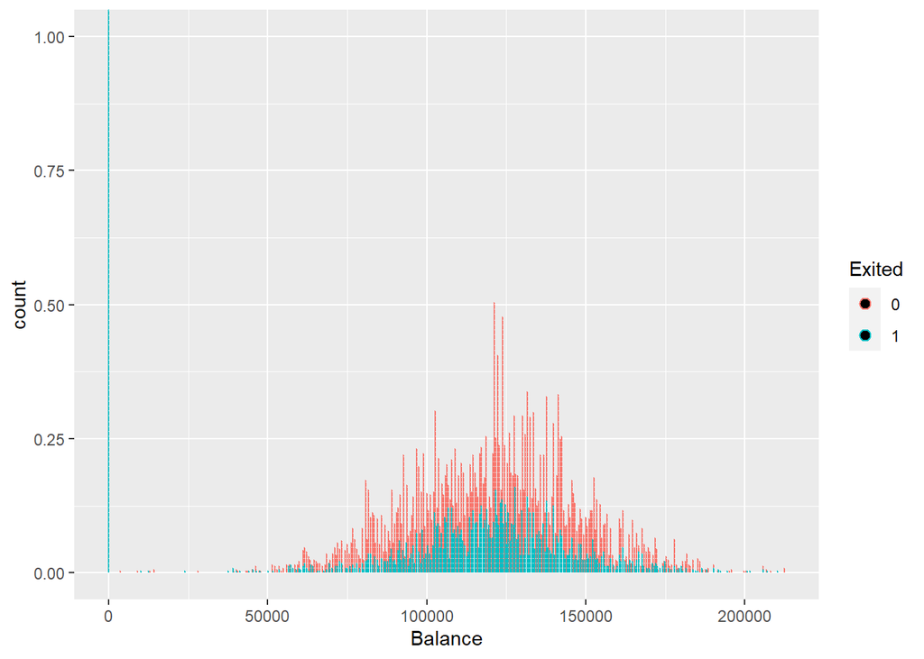

```r
churn_train %>%
  ggplot(aes(x = Balance, color = Exited)) + geom_dotplot(binwidth = 500)
```

## Step 5 - Building and evaluation of predictive classification models

Now that you know a little more about the data, it’s time to start building a few classification models for `Exited`. We will start out using overall prediction accuracy as our metric but we might want to consider other metrics.

**QUESTION** Why might overall prediction accuracy not be the most appropriate metric to consider? What other metrics might be important and why?

> Overall prediction accuracy may not be the most appropriate metric to consider because as noted earlier with the counts of people who either exited or did not, our null model is going to be able to already predict about 80% accuracy if it assumes that nobody exits their loan position. Meanwhile, I believe that our primary interest is Recall(sensitivity). This is because we are interested in predicting which clients are going to exit their positions with the bank; therefore, we want to maximize our prediciton of the people we predict that actually leave relative to all of the people that we predict will leave. In other words, I want to be able to have a high prediction rate for who is actually going to leave the bank (we want to minimize the number of people we predict to leave that do not actually leave).

### Fit a null model

A very simple model would be to simply predict that `Exited` is equal to 0. On the training data we saw that we’d be ~80% accurate.

Let’s create this null model and run a confusion matrix on its “predictions” for both the training and the test data.

```r
# Create a vector of 0's
model_train_null <- rep(0, nrow(churn_train))
model_test_null <- rep(0, nrow(churn_test))

cm_train_null <- caret::confusionMatrix(as.factor(model_train_null), churn_train$Exited, positive = "1")
cm_train_null
```

```
## Confusion Matrix and Statistics
##
##           Reference
## Prediction     0     1
##          0 20880  5527
##          1     0     0
##
##                Accuracy : 0.7907
##                  95% CI : (0.7857, 0.7956)
##     No Information Rate : 0.7907
##     P-Value [Acc > NIR] : 0.5036
##
##                   Kappa : 0
##
##  Mcnemar's Test P-Value : <2e-16
##
##             Sensitivity : 0.0000
##             Specificity : 1.0000
##          Pos Pred Value :    NaN
##          Neg Pred Value : 0.7907
##              Prevalence : 0.2093
##          Detection Rate : 0.0000
##    Detection Prevalence : 0.0000
##       Balanced Accuracy : 0.5000
##
##        'Positive' Class : 1
##
```

```r
cm_test_null <- caret::confusionMatrix(as.factor(model_test_null), churn_test$Exited, positive = "1")
cm_test_null
```

```
## Confusion Matrix and Statistics
##
##           Reference
## Prediction    0    1
##          0 5219 1381
##          1    0    0
##
##                Accuracy : 0.7908
##                  95% CI : (0.7807, 0.8005)
##     No Information Rate : 0.7908
##     P-Value [Acc > NIR] : 0.5072
##
##                   Kappa : 0
##
##  Mcnemar's Test P-Value : <2e-16
##
##             Sensitivity : 0.0000
##             Specificity : 1.0000
##          Pos Pred Value :    NaN
##          Neg Pred Value : 0.7908
##              Prevalence : 0.2092
##          Detection Rate : 0.0000
##    Detection Prevalence : 0.0000
##       Balanced Accuracy : 0.5000
##
##        'Positive' Class : 1
##
```

**QUESTION** A few questions:

- Are you surprised that the performance of the null model is almost identical on test and train? Why or why not?
- Explain the sensitivity and specificity values.

> I am not surprised that the performance of the null model is almost identical on the test and train data. The training data had ~27,000 observations to train on; therefore, I would expect its accuracy to be well identified. In terms of the sensitivity and specificity values: sensitivity refers to the proportion of values we correctly predicted of all predictions we made for a classifier while sensitivity refers to the proportion of values we correctly predicted with regards to all values that were actually true for a classifier. In this example, sensitivity is 0 because we didn’t predict anybody to leave the bank and specificity is 1 because we were able to predict all of the individuals that didn’t leave the bank (making the assumption nobody would leave).

So, as we begin fitting more complicated models, remember that we need to outperform the null model to make it worth it to use more complicated models.

Now I’m going to ask you to fit three models:

- a logistic regression model
- a simple decision tree
- a random forest

We covered all three of these modeling techniques in the class notes.

For each model type, you should:

- fit the model on the training data,
- assess the model’s performance on the training data using the `confusionMatrix` function,
- use the model to make predictions on the test data,
- assess the model’s performance on the test data using the `confusionMatrix` function,
- discuss the results

In your discussion of the results you should talk about things like:

- how accurate is the model in predicting on the test data
- is there evidence of overfitting?
- how does the model do in terms of other metrics like sensitivity and specificity
- other things you deem important.

### Fit logistic regression models

You’ll start by creating a logistic regression model to predict `Exited`. Since there are not that many variables, let’s use all of them. Here’s a code skeleton to help you get started:

**Hint**: There’s an easy way to specify your model formula to include all of the predictor variables without typing out all the variable names.

```r
# Fit model to training data
# A better model exists with Geography + Gender + Age + Balance * NumOfProducts + IsActiveMember
model_lr1 <- glm(Exited ~ .,
  data=churn_train, family=binomial(link="logit"))

## Convert fitted model values to fitted classes. Use 0.5 as the
#  threshold for classifying a case as a 1.

class_train_lr1 <- as.factor(ifelse(model_lr1$fitted.values > 0.5, 1, 0))


cm_train_lr1 <- confusionMatrix(class_train_lr1, model_lr1$data$Exited, positive="1")
cm_train_lr1
```

```
## Confusion Matrix and Statistics
##
##           Reference
## Prediction     0     1
##          0 19835  2693
##          1  1045  2834
##
##                Accuracy : 0.8584
##                  95% CI : (0.8542, 0.8626)
##     No Information Rate : 0.7907
##     P-Value [Acc > NIR] : < 2.2e-16
##
##                   Kappa : 0.5197
##
##  Mcnemar's Test P-Value : < 2.2e-16
##
##             Sensitivity : 0.5128
##             Specificity : 0.9500
##          Pos Pred Value : 0.7306
##          Neg Pred Value : 0.8805
##              Prevalence : 0.2093
##          Detection Rate : 0.1073
##    Detection Prevalence : 0.1469
##       Balanced Accuracy : 0.7314
##
##        'Positive' Class : 1
##
```

Now, let’s predict on test data.

```r
pred_lr1 <- predict(model_lr1, newdata = churn_test, type = "response")

class_test_lr1 <- as.factor(ifelse(pred_lr1 > 0.5, 1, 0))

cm_test_lr1 <- confusionMatrix(class_test_lr1, churn_test$Exited, positive="1")
cm_test_lr1
```

```
## Confusion Matrix and Statistics
##
##           Reference
## Prediction    0    1
##          0 4941  696
##          1  278  685
##
##                Accuracy : 0.8524
##                  95% CI : (0.8436, 0.8609)
##     No Information Rate : 0.7908
##     P-Value [Acc > NIR] : < 2.2e-16
##
##                   Kappa : 0.4982
##
##  Mcnemar's Test P-Value : < 2.2e-16
##
##             Sensitivity : 0.4960
##             Specificity : 0.9467
##          Pos Pred Value : 0.7113
##          Neg Pred Value : 0.8765
##              Prevalence : 0.2092
##          Detection Rate : 0.1038
##    Detection Prevalence : 0.1459
##       Balanced Accuracy : 0.7214
##
##        'Positive' Class : 1
##
```

**QUESTION/DISCUSSION** How did accuracy, sensitivity and specificity change when predicting on test data instead of the training data?

Now change the threshold from 0.5 to 0.4 and create a new model using this new threshold. How does the sensitivity and specificity change as compared to our first logistic regression model? Explain why this happens?

```r
pred_lr2 <- predict(model_lr1, newdata = churn_test, type = "response")

class_test_lr2 <- as.factor(ifelse(pred_lr2 > 0.4, 1, 0))

cm_test_lr2 <- confusionMatrix(class_test_lr2, churn_test$Exited, positive="1")
cm_test_lr2
```

```
## Confusion Matrix and Statistics
##
##           Reference
## Prediction    0    1
##          0 4769  569
##          1  450  812
##
##                Accuracy : 0.8456
##                  95% CI : (0.8367, 0.8542)
##     No Information Rate : 0.7908
##     P-Value [Acc > NIR] : < 2.2e-16
##
##                   Kappa : 0.5182
##
##  Mcnemar's Test P-Value : 0.0002186
##
##             Sensitivity : 0.5880
##             Specificity : 0.9138
##          Pos Pred Value : 0.6434
##          Neg Pred Value : 0.8934
##              Prevalence : 0.2092
##          Detection Rate : 0.1230
##    Detection Prevalence : 0.1912
##       Balanced Accuracy : 0.7509
##
##        'Positive' Class : 1
##
```

> When lowering the logistic regression threshold down to 40% instead of 50%, my model saw about a 1% drop-off in accuracy with the test set, about 4% drop with specificity, and about a 10% gain of sensitivity. This is actually good despite the falling accuracy and specifcity because we want to correctly predict the people taht are going to leave.. the true positves / true positives + false negatives.

### Fit simple decision tree model

Now create a simple decision tree model to predict `Exited`. Again, use all the variables.

```r
model_tree1 <- rpart(Exited ~ . , data=churn_train)

class_train_tree1 <- predict(model_tree1, type="class")

cm_train_tree1 <- confusionMatrix(class_train_tree1, churn_train$Exited, positive="1")
cm_train_tree1
```

```
## Confusion Matrix and Statistics
##
##           Reference
## Prediction     0     1
##          0 19847  2723
##          1  1033  2804
##
##                Accuracy : 0.8578
##                  95% CI : (0.8535, 0.862)
##     No Information Rate : 0.7907
##     P-Value [Acc > NIR] : < 2.2e-16
##
##                   Kappa : 0.5158
##
##  Mcnemar's Test P-Value : < 2.2e-16
##
##             Sensitivity : 0.5073
##             Specificity : 0.9505
##          Pos Pred Value : 0.7308
##          Neg Pred Value : 0.8794
##              Prevalence : 0.2093
##          Detection Rate : 0.1062
##    Detection Prevalence : 0.1453
##       Balanced Accuracy : 0.7289
##
##        'Positive' Class : 1
##
```

Create a plot of your decision tree.

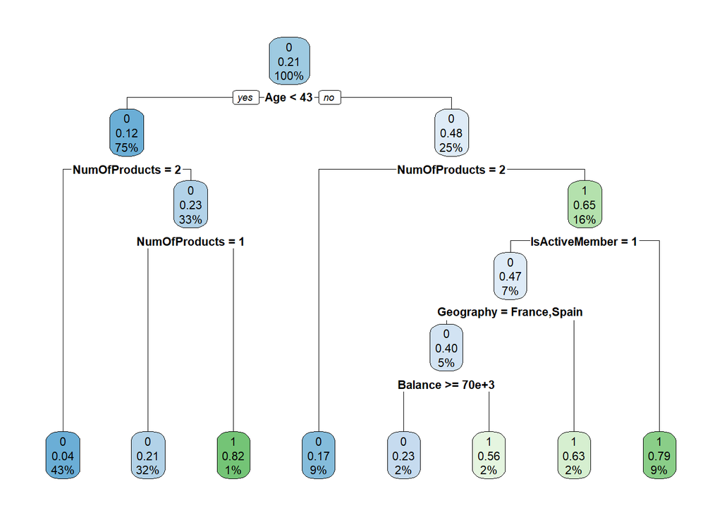

```r
rpart.plot(model_tree1)
```

Explain the bottom left node of your tree. What conditions have to be true for a case to end up being classified by that node? What do those three numbers in the node mean? What does the color of the node mean?

Now, let’s predict on test data.

```r
pred_tree1 <- predict(model_tree1, newdata = churn_test, type = "class")

cm_test_tree1 <- confusionMatrix(pred_tree1, churn_test$Exited, positive="1")
cm_test_tree1
```

```
## Confusion Matrix and Statistics
##
##           Reference
## Prediction    0    1
##          0 4962  703
##          1  257  678
##
##                Accuracy : 0.8545
##                  95% CI : (0.8458, 0.863)
##     No Information Rate : 0.7908
##     P-Value [Acc > NIR] : < 2.2e-16
##
##                   Kappa : 0.5012
##
##  Mcnemar's Test P-Value : < 2.2e-16
##
##             Sensitivity : 0.4909
##             Specificity : 0.9508
##          Pos Pred Value : 0.7251
##          Neg Pred Value : 0.8759
##              Prevalence : 0.2092
##          Detection Rate : 0.1027
##    Detection Prevalence : 0.1417
##       Balanced Accuracy : 0.7209
##
##        'Positive' Class : 1
##
```

**QUESTION** How does the performance of the decision tree compare to your logistic regression model?

## Fit random forest model

Finally, fit a random forest model.

```r
library(randomForest)
churn_rf <- randomForest(Exited ~ .,
                         data=churn_train,
                         mtry=4,
                         importance=TRUE)
```

Now, let’s predict on test data.

```r
churn_rf_pred <- predict(churn_rf, churn_test, type="class")
cm.rf.pred <- confusionMatrix(churn_rf_pred, churn_test$Exited, positive = "1")
cm.rf.pred
```

```
## Confusion Matrix and Statistics
##
##           Reference
## Prediction    0    1
##          0 4887  619
##          1  332  762
##
##                Accuracy : 0.8559
##                  95% CI : (0.8472, 0.8643)
##     No Information Rate : 0.7908
##     P-Value [Acc > NIR] : < 2.2e-16
##
##                   Kappa : 0.5285
##
##  Mcnemar's Test P-Value : < 2.2e-16
##
##             Sensitivity : 0.5518
##             Specificity : 0.9364
##          Pos Pred Value : 0.6965
##          Neg Pred Value : 0.8876
##              Prevalence : 0.2092
##          Detection Rate : 0.1155
##    Detection Prevalence : 0.1658
##       Balanced Accuracy : 0.7441
##
##        'Positive' Class : 1
##
```

**QUESTION** Summarize the performance of all three of your models (logistic, tree, random forest)? Is their evidence of overfitting in any of these model and what is your evidence for your answer? Add code chunks as needed.

> All three of these models predicted pretty similar results with accuracy around 85%, sensitivity around 50-55%, and specificity from 90-95%. Out of the three models, I would probably choose the random forest because I desired to maximiize sensitivity (which still isn’t great). I don’t believe there is any overfitting for the models as they all have similar metrics based on their training data to test data. Thus, they aren’t fit super well in the training phase, at least comparatively to their ability to predict test results. I wonder how the measurement statistics would’ve come back if I tried bootstrapping/bagging or boosting or even tried to change my parameters to not include all of the variables.

```r
cm_test_lr1$overall
```

```
##       Accuracy          Kappa  AccuracyLower  AccuracyUpper   AccuracyNull
##   8.524242e-01   4.981966e-01   8.436361e-01   8.608997e-01   7.907576e-01
## AccuracyPValue  McnemarPValue
##   6.534526e-38   1.014409e-40
```

```r
cm_train_lr1$overall
```

```
##       Accuracy          Kappa  AccuracyLower  AccuracyUpper   AccuracyNull
##   8.584466e-01   5.196760e-01   8.541838e-01   8.626304e-01   7.906994e-01
## AccuracyPValue  McnemarPValue
##  7.001546e-177  7.772541e-160
```

```r
cm_test_lr2$overall
```

```
##       Accuracy          Kappa  AccuracyLower  AccuracyUpper   AccuracyNull
##   8.456061e-01   5.181742e-01   8.366607e-01   8.542449e-01   7.907576e-01
## AccuracyPValue  McnemarPValue
##   4.188018e-30   2.185615e-04
```

```r
cm_train_tree1$overall
```

```
##       Accuracy          Kappa  AccuracyLower  AccuracyUpper   AccuracyNull
##   8.577650e-01   5.158438e-01   8.534938e-01   8.619572e-01   7.906994e-01
## AccuracyPValue  McnemarPValue
##  3.360475e-173  3.431777e-167
```

```r
cm_test_tree1$overall
```

```
##       Accuracy          Kappa  AccuracyLower  AccuracyUpper   AccuracyNull
##   8.545455e-01   5.012253e-01   8.458075e-01   8.629688e-01   7.907576e-01
## AccuracyPValue  McnemarPValue
##   1.490862e-40   8.919939e-47
```

```r
cm.rf.pred$overall
```

```
##       Accuracy          Kappa  AccuracyLower  AccuracyUpper   AccuracyNull
##   8.559091e-01   5.285492e-01   8.472037e-01   8.642987e-01   7.907576e-01
## AccuracyPValue  McnemarPValue
##   2.634567e-42   1.789814e-20
```

**QUESTION** If you had to pick one to use in an actual financial environment, which model would you use and why? As a manager in charge of retention, what model performance metrics are you most interested in? What are the basic tradeoffs you see in terms of the initiatives you might undertake in response to such a model? For example, if you were really interested in reducing the number of customers exiting, maybe there are some things you might do to incent high risk (of exiting) customers to stay. Discuss.

**HACKER EXTRA**

Create a variable importance plot for your random forest to try to get a sense of which variables are most important in predicting customers likely to churn. Build another random forest using only the top 5 or so variables suggested by the importance plot. How does the performance of this reduced model compare to the original model?

```r
churn_rf$importance
```

```
##                            0            1 MeanDecreaseAccuracy MeanDecreaseGini
## CreditScore     0.0006608712 0.0008047967         0.0006895815        1168.1949
## Geography       0.0019861442 0.0523843750         0.0125393255         331.9524
## Gender          0.0018900196 0.0126935484         0.0041532881         177.7078
## Age             0.0280235531 0.1344233826         0.0503004671        2071.6587
## Tenure          0.0008351813 0.0003584598         0.0007330342         856.7358
## Balance         0.0252776230 0.0275965460         0.0257675951         914.9381
## NumOfProducts   0.0537702413 0.1326959865         0.0702938757        1252.4341
## HasCrCard       0.0003240457 0.0009121140         0.0004480450         139.9940
## IsActiveMember  0.0122189012 0.0407747358         0.0181987970         403.8568
## EstimatedSalary 0.0006658725 0.0008902854         0.0007120598        1229.9869
```

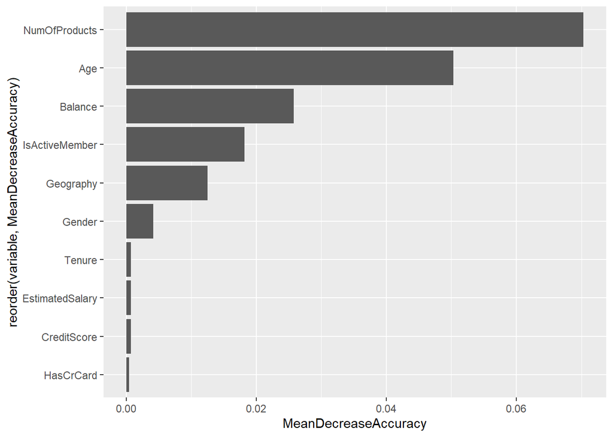

```r
df_imp <- as.data.frame(churn_rf$importance) %>%
  arrange(desc(MeanDecreaseGini))

df_imp <- tibble:: rownames_to_column(df_imp, "variable")
ggplot(df_imp) + geom_bar(aes(x=reorder(variable, MeanDecreaseAccuracy), y = MeanDecreaseAccuracy),
                          stat = "identity") + coord_flip()
```

```r
rf_imp <- randomForest(Exited ~ NumOfProducts + Age + Balance + IsActiveMember + Geography,
                       data = churn_train)

pred.rf.imp <- predict(rf_imp, churn_test, type="class")
imp.rf.pred <- confusionMatrix(pred.rf.imp, churn_test$Exited, positive = "1")
imp.rf.pred
```

```
## Confusion Matrix and Statistics
##
##           Reference
## Prediction    0    1
##          0 4980  681
##          1  239  700
##
##                Accuracy : 0.8606
##                  95% CI : (0.852, 0.8689)
##     No Information Rate : 0.7908
##     P-Value [Acc > NIR] : < 2.2e-16
##
##                   Kappa : 0.5226
##
##  Mcnemar's Test P-Value : < 2.2e-16
##
##             Sensitivity : 0.5069
##             Specificity : 0.9542
##          Pos Pred Value : 0.7455
##          Neg Pred Value : 0.8797
##              Prevalence : 0.2092
##          Detection Rate : 0.1061
##    Detection Prevalence : 0.1423
##       Balanced Accuracy : 0.7305
##
##        'Positive' Class : 1
##
```